# Dashboard Development with ridgeline plot

Michiel Noback

May 17, 2021

## preliminaries

Load required libraries

```r
## Note that the chunk has 'message=FALSE'
library(readr)
library(dplyr)
library(tidyr)
library(ggplot2)
library(ggridges)
```

# A COVID-19 dashboard

## Background

This log describes the development of a custom COVID dashboard. The focus will be on municipalities (“gemeentes”). By default a top-ten of municipalities with highest COVID infections should be displayed, but users should also be able to display their own selection.

## The plot

I want to develop a ridgeline plot for cases per municipality.

The basic ridgeline plot, as presented in the [R Graph Gallery](https://www.r-graph-gallery.com/294-basic-ridgeline-plot.html), is this:

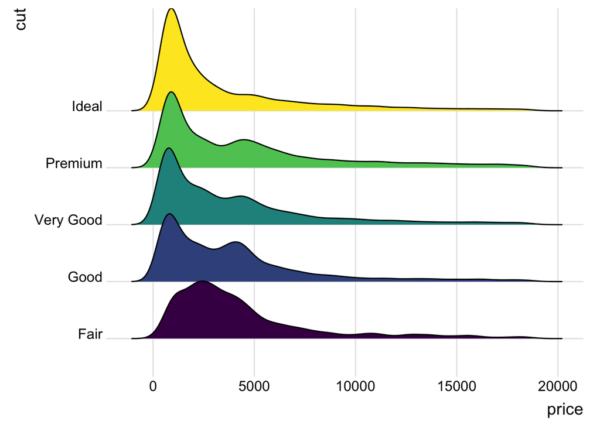

```r
 #from library ggridges

# Diamonds dataset is provided by R natively
#head(diamonds)

# basic example
ggplot(diamonds, aes(x = price, y = cut, fill = cut)) +
  geom_density_ridges() +
  theme_ridges() +
  theme(legend.position = "none")
```

## The data

Two datasets are required: COVID data and population data.

### Covid-19 data

From the CBS VOVID-19 data portal (https://data.rivm.nl/covid-19/) the file `COVID-19_aantallen_gemeente_per_dag.csv` was downloaded.

```r
filename = "COVID-19_aantallen_gemeente_per_dag.csv"
local_folder = "data/"
url <- paste0("https://data.rivm.nl/covid-19/", filename)
local_file <- paste0(local_folder, filename)
```

In the chunck below `eval =` can be set to `TRUE` to download a new version of the file.

```r
download.file(url = url, destfile = local_file)
```

### Population data

The population data were downloaded from: https://opendata.cbs.nl/#/CBS/nl/dataset/03759ned/table?dl=39E0B Where selection was made to only get total population sizes without distinction of age, marital status or gender. Since automatic download is not possible via this web form, the file was downloaded manually as `Bevolking__geslacht__leeftijd__regio_21042021_115647.csv` and placed under the data folder.

## Data loading

Both files were loaded and investigated cursorily.

### COVID data

Read in and inspect contents:

```r
covid_data <- read_delim(file = local_file,
                                delim = ";")
#store as single variable and delete column
current_report_date <- covid_data[1, "Date_of_report"]
covid_data <- covid_data %>%
    select(-Date_of_report)

covid_data %>% head()
```

```
## # A tibble: 6 x 11
##   Date_of_publica… Municipality_co… Municipality_na… Province Security_region…
##   <date>           <chr>            <chr>            <chr>    <chr>
## 1 2020-02-27       GM0014           Groningen        Groning… VR01
## 2 2020-02-27       GM0034           Almere           Flevola… VR25
## 3 2020-02-27       GM0037           Stadskanaal      Groning… VR01
## 4 2020-02-27       GM0047           Veendam          Groning… VR01
## 5 2020-02-27       GM0050           Zeewolde         Flevola… VR25
## 6 2020-02-27       GM0059           Achtkarspelen    Fryslân  VR02
## # … with 6 more variables: Security_region_name <chr>,
## #   Municipal_health_service <chr>, ROAZ_region <chr>, Total_reported <dbl>,
## #   Hospital_admission <dbl>, Deceased <dbl>
```

This seems like a reasonable starting point.

### Population data

Read in and inspect contents:

```r
pop_file <- "data/Bevolking__geslacht__leeftijd__regio_21042021_115647.csv"
pop_data_raw <- read_delim(file = pop_file,
                       delim = ";")
#OK, but change colnames to remove spaces
tmp_colnames <- colnames(pop_data_raw)
tmp_colnames[3] <- "Burgerlijke_staat" # replaces 'Burgerlijke staat'
tmp_colnames[5] <- "Regios"     #replaces Regio's
tmp_colnames[6] <- "Bevolking"  #replaces 'Bevolking op 1 januari (aantal)'
colnames(pop_data_raw) <- tmp_colnames

pop_data_raw %>% head()
```

```
## # A tibble: 6 x 6
##   Geslacht           Leeftijd Burgerlijke_staat     Perioden Regios    Bevolking
##   <chr>              <chr>    <chr>                    <dbl> <chr>         <dbl>
## 1 Totaal mannen en … Totaal   Totaal burgerlijke s…     1988 Aa en Hu…        NA
## 2 Totaal mannen en … Totaal   Totaal burgerlijke s…     2000 Aa en Hu…     24824
## 3 Totaal mannen en … Totaal   Totaal burgerlijke s…     2005 Aa en Hu…     25329
## 4 Totaal mannen en … Totaal   Totaal burgerlijke s…     2019 Aa en Hu…     25386
## 5 Totaal mannen en … Totaal   Totaal burgerlijke s…     2020 Aa en Hu…     25445
## 6 Totaal mannen en … Totaal   Totaal burgerlijke s…     1988 Aalburg       10597
```

So there are population counts for several years. I am only interested in 2020 right now so will discard everything else. Also, some columns are not interesting right now:

```r
pop_data_raw %>% group_by(Geslacht) %>% summarize(count = n(), .groups = "drop")
pop_data_raw %>% group_by(Leeftijd) %>% summarize(count = n(), .groups = "drop")
pop_data_raw %>% group_by(Burgerlijke_staat) %>% summarize(count = n(), .groups = "drop")
```

```
## # A tibble: 1 x 2
##   Geslacht                 count
##   <chr>                    <int>
## 1 Totaal mannen en vrouwen  4150
## # A tibble: 1 x 2
##   Leeftijd count
##   <chr>    <int>
## 1 Totaal    4150
## # A tibble: 1 x 2
##   Burgerlijke_staat        count
##   <chr>                    <int>
## 1 Totaal burgerlijke staat  4150
```

Let’s clean up.

```r
pop_data <- pop_data_raw %>%
    filter(Perioden == 2020) %>%
    select(Regios, Bevolking) %>%
    drop_na()
head(pop_data)
```

```
## # A tibble: 6 x 2
##   Regios        Bevolking
##   <chr>             <dbl>
## 1 Aa en Hunze       25445
## 2 Aalsmeer          31859
## 3 Aalten            27121
## 4 Achtkarspelen     27843
## 5 Alblasserdam      20165
## 6 Albrandswaard     25590
```

## Combine data

```r
all_data <- covid_data %>%
    left_join(pop_data, by = c("Municipality_name" = "Regios"))
all_data
```

```
## # A tibble: 168,210 x 12
##    Date_of_publica… Municipality_co… Municipality_na… Province Security_region…
##    <date>           <chr>            <chr>            <chr>    <chr>
##  1 2020-02-27       GM0014           Groningen        Groning… VR01
##  2 2020-02-27       GM0034           Almere           Flevola… VR25
##  3 2020-02-27       GM0037           Stadskanaal      Groning… VR01
##  4 2020-02-27       GM0047           Veendam          Groning… VR01
##  5 2020-02-27       GM0050           Zeewolde         Flevola… VR25
##  6 2020-02-27       GM0059           Achtkarspelen    Fryslân  VR02
##  7 2020-02-27       GM0060           Ameland          Fryslân  VR02
##  8 2020-02-27       GM0072           Harlingen        Fryslân  VR02
##  9 2020-02-27       GM0074           Heerenveen       Fryslân  VR02
## 10 2020-02-27       GM0080           Leeuwarden       Fryslân  VR02
## # … with 168,200 more rows, and 7 more variables: Security_region_name <chr>,
## #   Municipal_health_service <chr>, ROAZ_region <chr>, Total_reported <dbl>,
## #   Hospital_admission <dbl>, Deceased <dbl>, Bevolking <dbl>
```

This fails! Groningen has no population count. Why? Look it up in the pop_data_raw:

```r
pop_data_raw %>% filter(grepl("Groningen", Regios))
```

```
## # A tibble: 10 x 6
##    Geslacht         Leeftijd Burgerlijke_staat   Perioden Regios       Bevolking
##    <chr>            <chr>    <chr>                  <dbl> <chr>            <dbl>
##  1 Totaal mannen e… Totaal   Totaal burgerlijke…     1988 Groningen (…    167929
##  2 Totaal mannen e… Totaal   Totaal burgerlijke…     2000 Groningen (…    173139
##  3 Totaal mannen e… Totaal   Totaal burgerlijke…     2005 Groningen (…    180604
##  4 Totaal mannen e… Totaal   Totaal burgerlijke…     2019 Groningen (…    231299
##  5 Totaal mannen e… Totaal   Totaal burgerlijke…     2020 Groningen (…    232874
##  6 Totaal mannen e… Totaal   Totaal burgerlijke…     1988 Midden-Gron…        NA
##  7 Totaal mannen e… Totaal   Totaal burgerlijke…     2000 Midden-Gron…        NA
##  8 Totaal mannen e… Totaal   Totaal burgerlijke…     2005 Midden-Gron…        NA
##  9 Totaal mannen e… Totaal   Totaal burgerlijke…     2019 Midden-Gron…     60899
## 10 Totaal mannen e… Totaal   Totaal burgerlijke…     2020 Midden-Gron…     60797
```

There it is: The city of Groningen is named “Groningen (gemeente)” in the pop-data dataset, whereas it is named “Groningen” in the COVID dataset. Apparently I will need another means to combine. The covid dataset has the column named “Municipality_code”. Unfortunately this is not present in the pop_data. I will check how often this happens, to see if a manual fix is the better option.

```r
all_data %>%
    distinct(Municipality_name, .keep_all = TRUE) %>%
    summarize(Total = n(),
              Missing = sum(is.na(Bevolking)))
```

```
## # A tibble: 1 x 2
##   Total Missing
##   <int>   <int>
## 1   353      10
```

Which are these?

```r
missing_mun_pop <- all_data %>%
    filter(is.na(Bevolking)) %>%
    distinct(Municipality_name) %>%
    pull(Municipality_name)
missing_mun_pop
```

```
##  [1] "Groningen"     "Utrecht"       "Laren"         "'s-Gravenhage"
##  [5] "Rijswijk"      "Middelburg"    "Beek"          "Stein"
##  [9] "Eemsdelta"     NA
```

So population data are missing for 10 municipalities.

```r
missing_combos <- tibble(Regios = character(0),
                         Bevolking = double(0),
                         municipality = character(0))
for (municipality in missing_mun_pop) {
    tmp <- pop_data %>%
        filter(grepl(municipality, Regios))
    tmp$municipality <- municipality
    missing_combos <- bind_rows(missing_combos, tmp)
}
print(missing_combos, n=Inf)
```

```
## # A tibble: 11 x 3
##    Regios                   Bevolking municipality
##    <chr>                        <dbl> <chr>
##  1 Groningen (gemeente)        232874 Groningen
##  2 Midden-Groningen             60797 Groningen
##  3 Utrecht (gemeente)          357597 Utrecht
##  4 Utrechtse Heuvelrug          49580 Utrecht
##  5 Laren (NH.)                  11280 Laren
##  6 's-Gravenhage (gemeente)    545838 's-Gravenhage
##  7 Rijswijk (ZH.)               54450 Rijswijk
##  8 Middelburg (Z.)              48822 Middelburg
##  9 Beek (L.)                    15865 Beek
## 10 Beekdaelen                   35938 Beek
## 11 Stein (L.)                   25007 Stein
```

For the purpose of this initial exploration, I consider a manual correction of names appropriate. If this app is going to have a serious user base, a better solution may have to be found.

```r
pop_data <- pop_data %>%
    mutate(Regios = ifelse(Regios == "Groningen (gemeente)", "Groningen", Regios)) %>%
    mutate(Regios = ifelse(Regios == "Utrecht (gemeente)", "Utrecht", Regios)) %>%
    mutate(Regios = ifelse(Regios == "Laren (NH.)", "Laren", Regios)) %>%
    mutate(Regios = ifelse(Regios == "'s-Gravenhage (gemeente)", "'s-Gravenhage", Regios)) %>%
    mutate(Regios = ifelse(Regios == "Rijswijk (ZH.)", "Rijswijk", Regios)) %>%
    mutate(Regios = ifelse(Regios == "Middelburg (Z.)", "Middelburg", Regios)) %>%
    mutate(Regios = ifelse(Regios == "Beek (L.)", "Beek", Regios)) %>%
    mutate(Regios = ifelse(Regios == "Stein (L.)", "Stein", Regios))
```

and recreate the merge

```r
all_data <- covid_data %>% left_join(pop_data, by = c("Municipality_name" = "Regios"))
all_data
```

```
## # A tibble: 168,210 x 12
##    Date_of_publica… Municipality_co… Municipality_na… Province Security_region…
##    <date>           <chr>            <chr>            <chr>    <chr>
##  1 2020-02-27       GM0014           Groningen        Groning… VR01
##  2 2020-02-27       GM0034           Almere           Flevola… VR25
##  3 2020-02-27       GM0037           Stadskanaal      Groning… VR01
##  4 2020-02-27       GM0047           Veendam          Groning… VR01
##  5 2020-02-27       GM0050           Zeewolde         Flevola… VR25
##  6 2020-02-27       GM0059           Achtkarspelen    Fryslân  VR02
##  7 2020-02-27       GM0060           Ameland          Fryslân  VR02
##  8 2020-02-27       GM0072           Harlingen        Fryslân  VR02
##  9 2020-02-27       GM0074           Heerenveen       Fryslân  VR02
## 10 2020-02-27       GM0080           Leeuwarden       Fryslân  VR02
## # … with 168,200 more rows, and 7 more variables: Security_region_name <chr>,
## #   Municipal_health_service <chr>, ROAZ_region <chr>, Total_reported <dbl>,
## #   Hospital_admission <dbl>, Deceased <dbl>, Bevolking <dbl>
```

```r
all_data %>%
    filter(is.na(Bevolking)) %>%
    distinct(Municipality_name, .keep_all = T)
```

```
## # A tibble: 2 x 12
##   Date_of_publica… Municipality_co… Municipality_na… Province Security_region…
##   <date>           <chr>            <chr>            <chr>    <chr>
## 1 2020-02-27       GM1979           Eemsdelta        Groning… VR01
## 2 2020-02-27       <NA>             <NA>             Groning… VR01
## # … with 7 more variables: Security_region_name <chr>,
## #   Municipal_health_service <chr>, ROAZ_region <chr>, Total_reported <dbl>,
## #   Hospital_admission <dbl>, Deceased <dbl>, Bevolking <dbl>
```

These last two will simply be removed.

```r
all_data <- all_data %>%
    filter(!is.na(Bevolking))
```

The data is already there so this should not be too difficult.

```r
normalize_counts <- function(x, normalizer) {
    (x / normalizer) * 100000
}
## This overwrites the existing column, so I'll stick to the regular mutate()
# all_data %>%
#     mutate(across(c("Total_reported", "Hospital_admission", "Deceased"), normalize_covid_counts, Bevolking))

all_data <- all_data %>%
    mutate(Total_norm = normalize_counts(Total_reported, Bevolking)) %>%
    mutate(Hospital_norm = normalize_counts(Hospital_admission, Bevolking)) %>%
    mutate(Deceased_norm = normalize_counts(Deceased, Bevolking))
```

## First attempt at plot

Here is a first plot using a manual selection of 5 cities. First select the requested rows by filtering on these cities.

```r
my_cities <- c("Groningen", "Delfzijl", "Amsterdam", "Eindhoven", "Leeuwarden")
selected_cities <- all_data %>%
    filter(Municipality_name %in% my_cities)
head(selected_cities, 10)
```

```
## # A tibble: 10 x 15
##    Date_of_publica… Municipality_co… Municipality_na… Province Security_region…
##    <date>           <chr>            <chr>            <chr>    <chr>
##  1 2020-02-27       GM0014           Groningen        Groning… VR01
##  2 2020-02-27       GM0080           Leeuwarden       Fryslân  VR02
##  3 2020-02-27       GM0363           Amsterdam        Noord-H… VR13
##  4 2020-02-27       GM0363           Amsterdam        Noord-H… VR13
##  5 2020-02-27       GM0772           Eindhoven        Noord-B… VR22
##  6 2020-02-28       GM0014           Groningen        Groning… VR01
##  7 2020-02-28       GM0080           Leeuwarden       Fryslân  VR02
##  8 2020-02-28       GM0363           Amsterdam        Noord-H… VR13
##  9 2020-02-28       GM0363           Amsterdam        Noord-H… VR13
## 10 2020-02-28       GM0772           Eindhoven        Noord-B… VR22
## # … with 10 more variables: Security_region_name <chr>,
## #   Municipal_health_service <chr>, ROAZ_region <chr>, Total_reported <dbl>,
## #   Hospital_admission <dbl>, Deceased <dbl>, Bevolking <dbl>,
## #   Total_norm <dbl>, Hospital_norm <dbl>, Deceased_norm <dbl>
```

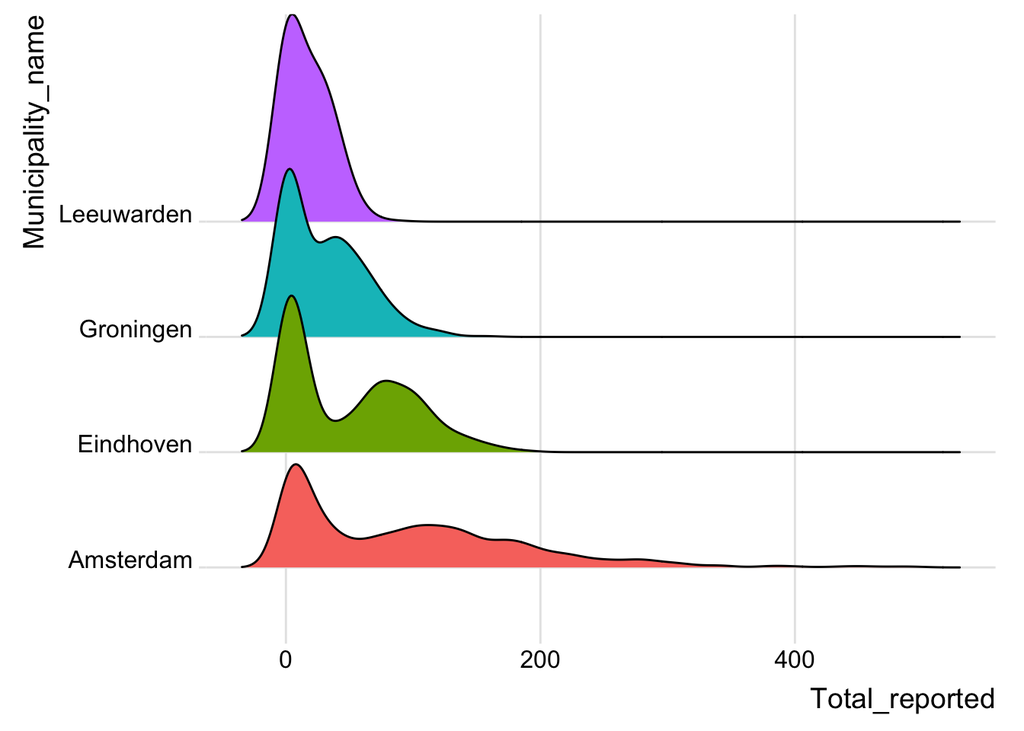

```r
ggplot(selected_cities, aes(x = Total_reported, y = Municipality_name, fill = Municipality_name)) +
  geom_density_ridges() +
  theme_ridges() +
  theme(legend.position = "none")
```

So. There is a serious problem here. I cannot put Date on x and Counts on y. The essence of ridgeline plot is that it is a *density* plot. I overlooked that one.

I will need to find another visualization for my purpose.

Here are two attempts: one with `geom_area` and another using `geom_smooth` to approximate the ridgeline plot using regular ggplot2 and a smoother. This is the one with `geom_area()`.

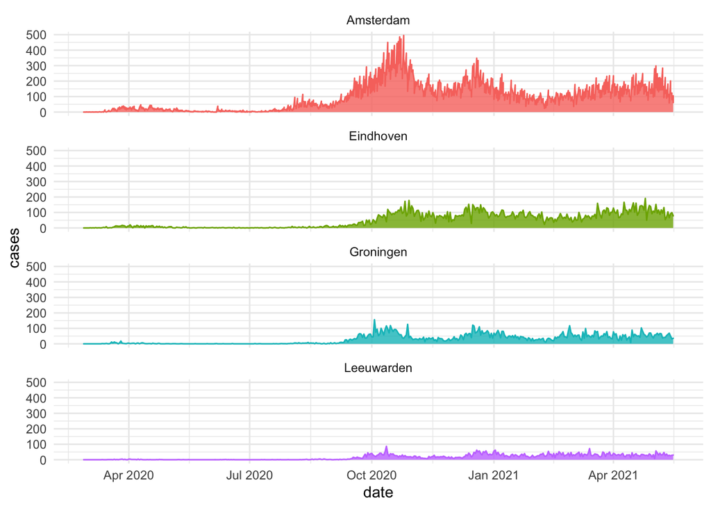

```r
ggplot(selected_cities, aes(x = Date_of_publication, y = Total_reported)) +
  geom_area(aes(color = Municipality_name, fill = Municipality_name),
           alpha = 0.8, position = position_dodge(0.8)) +
    facet_wrap(. ~ Municipality_name, ncol = 1) +
    labs(x = "date", y = "cases", fill = "City", color = "City") +
    theme_minimal() +
    theme(legend.position = "none")
```

This is the one with `geom_smooth()`. Note that the `span =` argument defines the amount of smoothing (averaging).

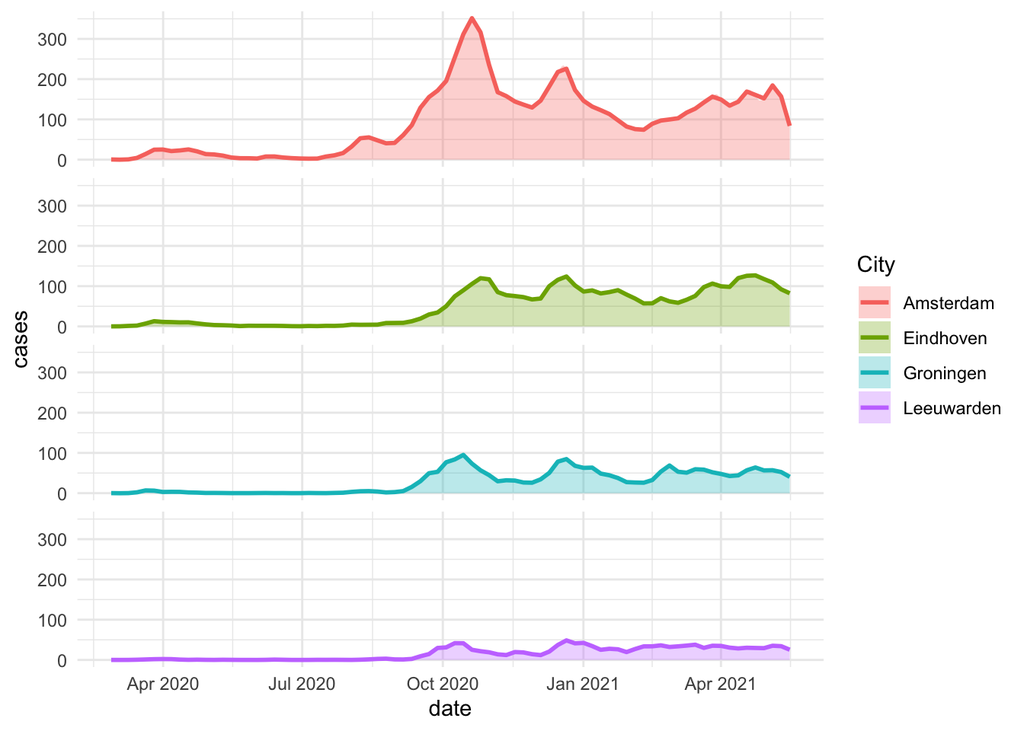

```r
loess_span <- 0.05

selected_cities <- selected_cities %>%
    group_by(Municipality_name) %>%
    mutate(loess_predict = predict(loess(Total_reported ~
                                  as.numeric(Date_of_publication),
                              span = loess_span)))

ggplot(selected_cities, aes(x = Date_of_publication, y = Total_reported)) +
    geom_smooth(aes(color = Municipality_name,
                    fill = Municipality_name),
                se = FALSE,
                span = loess_span,
                method = "loess",
                formula = y ~ x) +
    geom_ribbon(aes(ymin = 0,
                    ymax = loess_predict,
                    fill = Municipality_name),
                alpha = 0.3) +
    facet_wrap(. ~ Municipality_name, ncol = 1) +
    labs(x = "date", y = "cases", fill = "City", color = "City") +
    theme_minimal() +
    theme(
          strip.text.x = element_blank()
    )
```

Lowering the span too much gives warnings.

## Refactoring the code

I have put both functions (as well as data loading) in a separate source file for easy sourcing when used in a dashboard setting:

File: `dashboard_utilities.R` Functions:

- `load_data(covid_data_file, population_data_file)`
- `normalize_covid_counts(data, per)`
- `filter_data(data, date_from, date_to, municipalities)`
- `area_plot(data, date_from, date_to, municipalities)`
- `smoothed_plot(data, date_from, date_to, municipalities)`

`filter_data` is a helper function for the visualization functions to prevent code duplication but can be used separately.

Typical usage to load the dataset will now be like this

```r
rm(list = ls())
source('R/dashboard_utilities.R')
#download_new_covid_data()
all_data <- load_data()
all_data <- normalize_covid_counts(all_data)
```

## Testing selections on date and city

Here are some selections as test.

```r
library(lubridate)
my_cities <- c("Groningen", "Delfzijl", "Amsterdam", "Eindhoven", "Leeuwarden")
start_date = ymd("2021-04-19")
end_date = today() #ymd("2021-04-21")
print(end_date)
```

```
## [1] "2021-05-17"
```

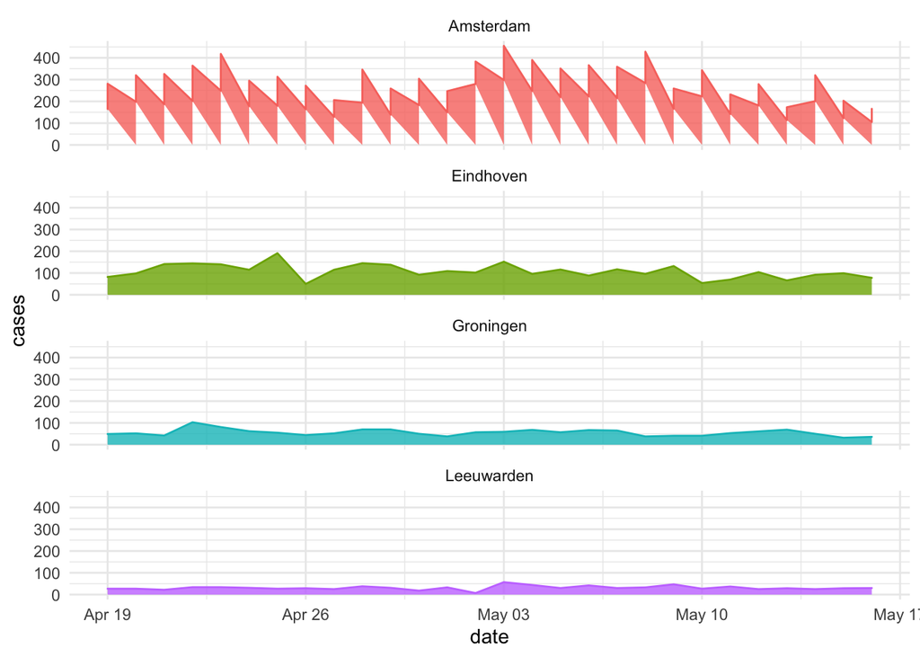

```r
area_plot(all_data, my_cities,
          date_from = start_date,
          date_to = end_date)
```

There is something funny going on with the “Amsterdam” plot when making smaller selections. Have a look at the selection for that city:

```r
filter_data(all_data, "Amsterdam", start_date, end_date) %>%
    select(c(2, 9:15))
```

```
## # A tibble: 56 x 8
##    Date_of_publica… ROAZ_region Total_reported Hospital_admiss… Deceased
##    <date>           <chr>                <dbl>            <dbl>    <dbl>
##  1 2021-04-19       Netwerk Ac…            165                5        1
##  2 2021-04-19       SpoedZorgN…            116                3        0
##  3 2021-04-20       Netwerk Ac…            198                3        1
##  4 2021-04-20       SpoedZorgN…            122                1        0
##  5 2021-04-21       Netwerk Ac…            187                8        0
##  6 2021-04-21       SpoedZorgN…            139                6        0
##  7 2021-04-22       Netwerk Ac…            202                3        0
##  8 2021-04-22       SpoedZorgN…            162                1        1
##  9 2021-04-23       Netwerk Ac…            249                3        0
## 10 2021-04-23       SpoedZorgN…            169                2        1
## # … with 46 more rows, and 3 more variables: Bevolking <dbl>, Total_norm <dbl>,
## #   Hospital_norm <dbl>
```

There is the problem: there are always two entries for a single day. A course of action should be taken: select one, add them, or calculate an average. Since they seem to refer to a region (“ROAZ_region”) I will sum them for municipalities. This is the way to do that.

```r
tmp <- filter(all_data, Municipality_name == "Amsterdam")
combined_counts <- tmp %>%
    group_by(Date_of_publication, Municipality_name) %>%
    summarize(Total = sum(Total_reported),
              Hospital = sum(Hospital_admission),
              Deaths = sum(Deceased),
              .groups = "drop")
combined_counts
```

```
## # A tibble: 445 x 5
##    Date_of_publication Municipality_name Total Hospital Deaths
##    <date>              <chr>             <dbl>    <dbl>  <dbl>
##  1 2020-02-27          Amsterdam             0        0      0
##  2 2020-02-28          Amsterdam             0        0      0
##  3 2020-02-29          Amsterdam             1        0      0
##  4 2020-03-01          Amsterdam             0        0      0
##  5 2020-03-02          Amsterdam             1        0      0
##  6 2020-03-03          Amsterdam             0        0      0
##  7 2020-03-04          Amsterdam             0        0      0
##  8 2020-03-05          Amsterdam             1        0      0
##  9 2020-03-06          Amsterdam             0        0      0
## 10 2020-03-07          Amsterdam             1        0      0
## # … with 435 more rows
```

Now for the smoothed plot.

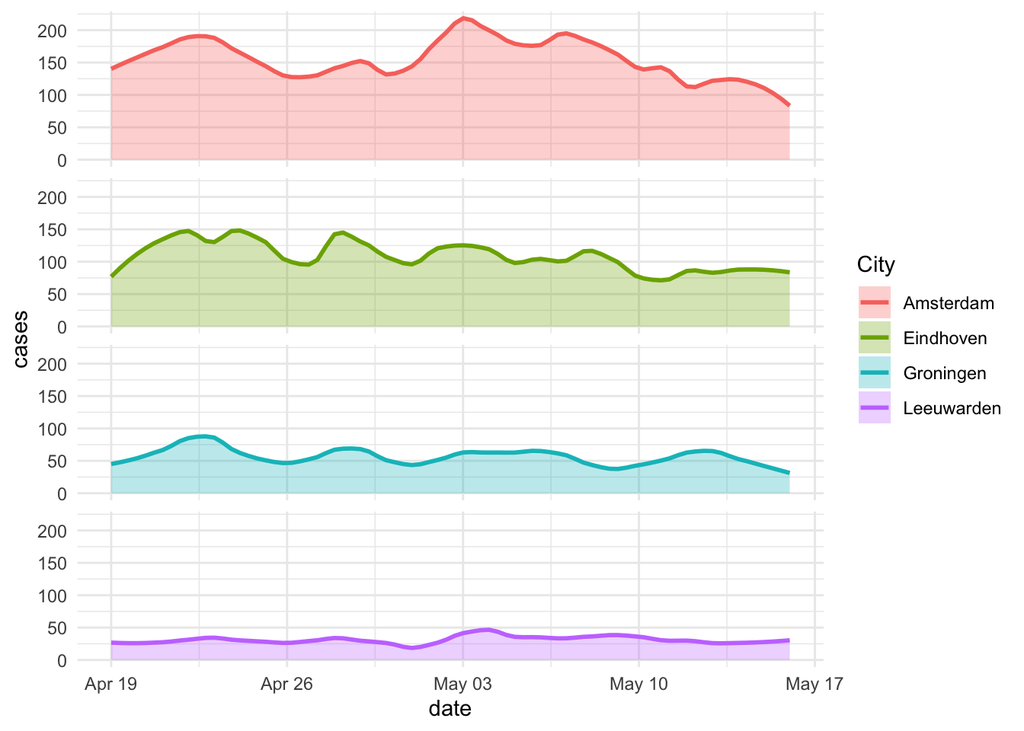

```r
start_date = ymd("2021-04-19")
end_date = today() #ymd("2021-04-21")
smoothed_plot(all_data,
            my_cities,
            date_from = start_date,
            date_to = end_date,
            loess_span = 0.25)
```

I like the second plot better, but the `loess_span` parameter needs to be dependent on the date-range interval. Since I have currently no time for that challenge I will stick to the area plot for now.